# Bruhn_C08_2

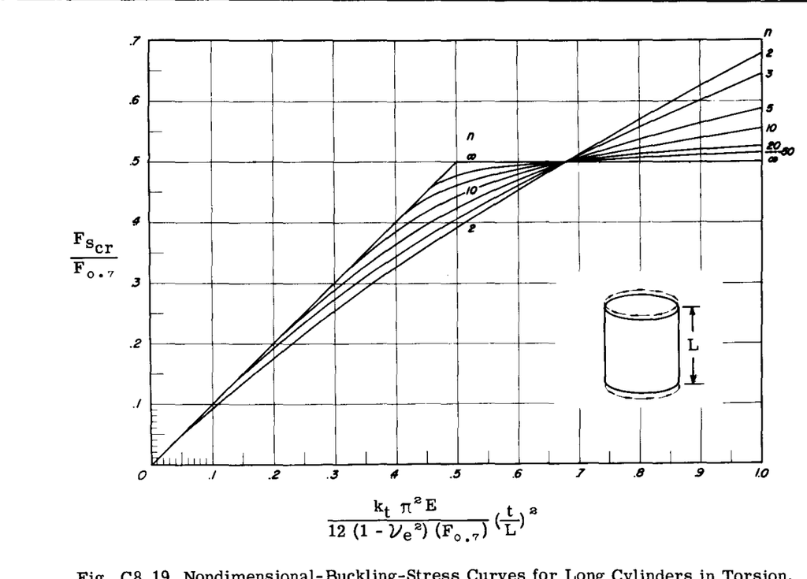

Fig. C8.19

$$\eta = (E_s/E)[(1 -
u_e^2)/(1 -
u^2)]^{3/4}$$

## C8.12 横せん断力による座屈

横荷重による曲げ下では、せん断応力も発生する。これらのせん断応力は中立軸で最大となり、円筒壁の最も離れた部分でゼロとなるが、ねじりせん断応力は円筒壁全体にわたって均一である。限られた試験では、ねじり座屈応力と比較して、横せん断荷重下での座屈せん断応力の方が高いことが示されている。産業界における一般的な手順は、 $k_t$ の1.25倍を使用することにより、ねじり下のせん断座屈応力を増加させることである。したがって、図 C8.18 でねじり下の座屈に対する $k_t$ を求め、式 C8.9 を使用する際にそれを1.25倍して、横せん断下の座屈応力を求める。

## C8.13 内圧を受ける円管の純ねじり座屈

内圧は円筒壁に引張力を生じさせるため、ねじり座屈応力は増加する。これは、ねじり座屈がせん断力によって生じる圧縮応力に起因するためである。

Hopkins と Brown（文献13）は、Donnell の式を用いて、ねじりを受ける円管の座屈応力に対する内圧の影響を計算し、その結果は試験結果と良好な一致を示した。

Crate、Batdorf、および Baab（文献14）は、試験データに適合させるために実験的な相互作用式を利用した。導出された相互作用式は以下の通りであった。

$$R_{st}^2 + R_p = 1 \quad \text{--- (C8.10)}$$

ここで、

$$\begin{aligned}
R_{st} & =
\frac{\text{負荷されたねじりせん断応力}}{\text{許容ねじりせん断応力}} \\
R_p & = \frac{\text{負荷された内圧}}{\text{外圧静水圧座屈圧力}}
\end{aligned}$$

$R_p$ は負の符号を持つことに注意されたい。外圧静水圧座屈圧力の値は、図 C8.15 を使用して決定できる。図 C8.22 は式 C8.10 からのプロットと試験データとの比較を示している。

## C8.14 横せん断力と内圧を受ける円管の座屈

この荷重系において、導出された相互作用式は式 C8.10 と同様である。

$$R_s + R_p = 1 \quad \text{--- (C8.11)}$$

ここで、

$$R_s = \frac{\text{負荷された横せん断応力}}{\text{許容横せん断応力}}$$

$R_p$ はセクション C8.13 で説明したものと同様である。

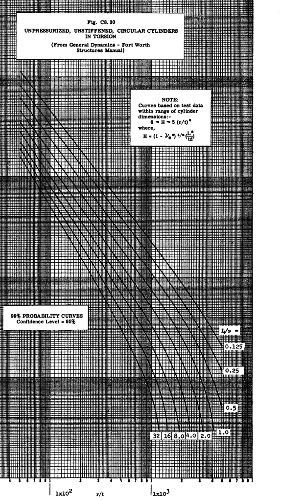

Fig. C8.20

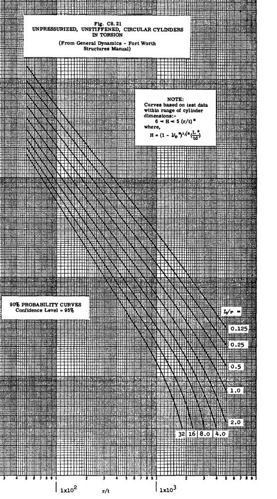

Fig. C8.21

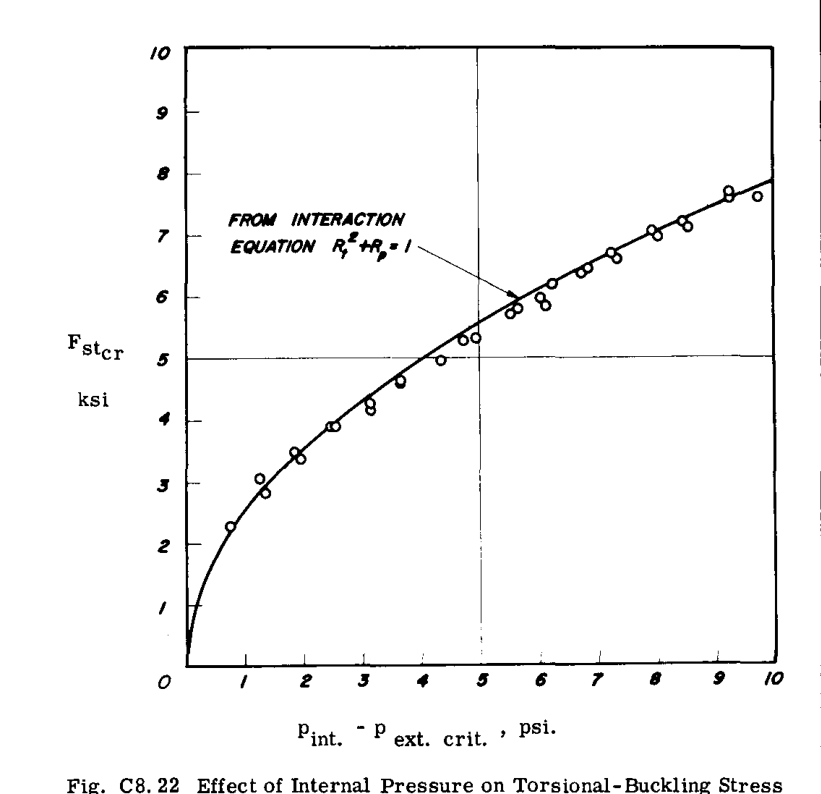

Fig. C8.22

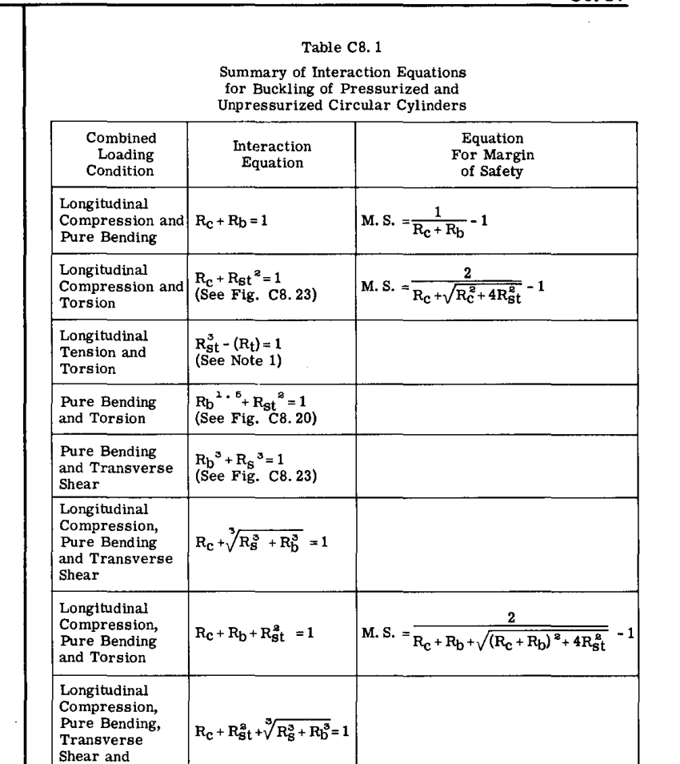

Table C8.1

## C8.15 複合荷重系における円管の座屈

宇宙航空構造物（ミサイルなど）に使用される円管が、軸応力、曲げ応力、およびせん断応力のうちの1つだけを発生させる荷重系にさらされることは極めて稀である。したがって、複合応力系の実際的なケース下で、座屈強度を安全に決定できる必要がある。この問題は、相互作用式を使用することによって処理される。

表 C8.1 は、いくつかの宇宙航空企業の構造設計マニュアルに登場する相互作用式をまとめたものである。これらの式は、試験データと照合することによって信頼性が証明されている。図 C8.23 は、3つの相互作用曲線のプロットを示している。これらの曲線は、円管が弱いかどうかを迅速に観察し、安全余裕を決定するのに有用である。

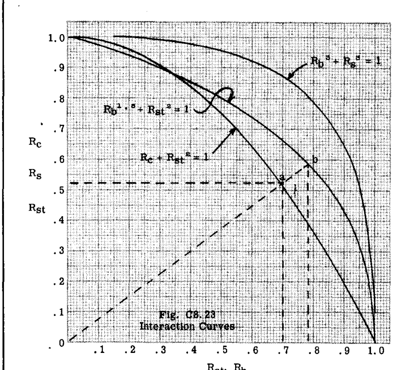

Fig. C8.23

## C8.16 円管モノコックシリンダーの座屈強度を求めるための例題

### 問題1. 軸圧縮強度

円管の半径 $r = 50$ インチ、長さ $L = 75$ インチ、壁厚 $t = 0.05$ インチである。材料はアルミニウム合金 2024-T3 であり、その弾性係数 $E_c = 10,700,000$ psi である。90%の確率に基づく設計曲線を使用した場合、この円管はどのような圧縮荷重に耐えられるか。

### 解答:

$$\begin{aligned}
r/t & = 50 / 0.05 = 1000 \\
L/r & = 75 / 50 = 1.5 \\
F_{cr} & = \frac{k_c \pi^2 E}{12(1 -
u_e^2)} \left(\frac{t}{L}\right)^2 \quad \text{--- (式 C8.2)}
\end{aligned}$$

座屈係数 $k_c$ を求めるために、図 C8.7 を使用する。

$$\begin{aligned}
Z & = \frac{L^2}{rt} \sqrt{1 -
u_e^2} \\
Z & = \frac{75^2}{50 \times 0.05} \sqrt{1 - 0.3^2} = 2140
\end{aligned}$$

図 C8.7 より、 $Z = 2140$ および $r/t = 1000$ を使用して、 $k_c = 280$ を読み取る。したがって、

$$F_{cr} = \frac{280 \pi^2 \times 10,700,000}{12(1 - 0.3^2)}
\left(\frac{0.05}{75}\right)^2 = 1210 \text{ psi}$$

座屈軸圧縮荷重は、

$$P = 2\pi rt F_{cr} = 2\pi \times 50 \times 0.05 \times 1205 = 18950
\text{ lb}$$

90%の確率と95%の信頼度に基づく図 C8.8b の設計曲線を使用する場合、 $r/t = 1000$ および $L/r = 1.5$ に対して $F_{cr}/E = 0.000121$ と読み取れる。したがって、

$$F_{cr} = 10,700,000 \times 0.000121 = 1295 \text{ psi}$$

この値に0.95の信頼度値を乗じると、1230 psi が得られ、これは図 C8.7 を使用して上記で得られた値と実質的に同じである。

$$P_a = 1295 \times 2\pi \times 0.05 \times 50 = 20350 \text{ lbs}$$

99%の確率と95%の信頼度が必要な場合は、図 C8.8a を使用する。 $r/t = 1000$ および $L/r = 1.5$ に対して、 $F_{cr}/E = 0.000082$ または $F_{cr} = 10,700,000 \times 0.000082 = 877$ psi と読み取れ、これにより軸方向座屈荷重は 13,700 lbs となる。したがって、99%の確率を要求すると、座屈荷重は大幅に減少する。

### 問題2. 曲げ強度

問題1と同じ円管をこの例題でも使用する。90%の確率の下で、この円管を座屈させる曲げモーメントはいくらか。

### 解答:

図 C8.12 の曲線を使用する。 $r/t = 1000$ および $L/r = 1.5$ に対して、図 C8.12 から曲げ座屈係数 $C_b = 0.16$ と読み取れる。

$$\begin{aligned}
F_{bcr} & = C_b E t / r \quad \text{--- (式 C8.5)} \\
& = 0.16 \times 10,700,000 \times 0.05 / 50 = 1710 \text{ psi}
\end{aligned}$$

この座屈応力で発生する曲げモーメントは、

$$\begin{aligned}
M & = F_{bcr} I/r = F_{bcr} \pi r^2 t \\
& = 1710 \times \pi \times 50^2 \times 0.05 = 670,000 \text{ in.
lb.}
\end{aligned}$$

90%の確率と95%の信頼度に基づく図 C8.13a を使用する場合、 $r/t = 1000$ および $L/r = 1.5$ に対して $F_{bcr}/E$ は 0.000160 であると読み取れる。したがって、

$$F_{bcr} = 10,700,000 \times 0.000160 = 1710 \text{ psi}$$

図 C8.12 を読み取るのは困難であるため、設計では図 C8.13a を使用することが推奨される。

99%の確率が必要な場合は、図 C8.13 を使用して $F_{bcr}/E = 0.000092$ を得、これにより $F_{bcr} = 10,700,000 \times 0.000092 = 985$ psi となり、90%の確率における 1710 に対抗する。

### 問題3. ねじり強度

問題1と同じ円管。この円管はどのようなねじりモーメントを発生させるか。

### 解答:

図 C8.18 の設計曲線を使用する。

$$Z = \frac{L^2}{rt} \sqrt{1 -
u_e^2} = \frac{75^2}{50 \times 0.05} \sqrt{1 - 0.3^2} = 2140$$

この $Z$ の値に対して、図 C8.18 からねじり座屈係数 $k_t$ を 170 と読み取る。

この座屈応力によって発生するねじりモーメントは、

$$\begin{aligned}
T & = F_{stcr} J/r, \quad J/r = 2\pi r^3 t / r = 2\pi r^2 t \\
& \text{したがって、} \\
T & = F_{stcr} 2\pi r^2 t \\
T & = 735 \times 2\pi \times 50^2 \times 0.05 = 578,000 \text{ in.
lbs.}
\end{aligned}$$

結果は、それぞれ 99% と 90% の確率、および 95% の信頼度に基づく図 C8.20 と C8.21 を使用しても計算される。図 C8.21 を使用すると、

$r/t = 1000$ および $L/r = 1.5$ に対して、 $F_{st}/E = 0.000082$ と読み取れる。したがって、 $F_{st} = 0.000082 \times 10,700,000 = 876$ psi となる。 $T = 876 \times 2\pi \times 50^2 \times 0.05 = 688,000$ in. lbs. である。

99%の確率用の図 C8.20 を使用すると、 $F_{st}/E = 0.000060$ と読み取れ、これにより $F_{st} = 642$ psi となり、許容トルク $T = 504,000$ in. lbs. が得られる。

### 問題4. 複合圧縮と曲げ

問題1の円管に、軸圧縮荷重 $P = 10,700$ lbs および曲げモーメント $M = 282,000$ in. lbs が加わっている。90%の確率と95%の信頼度におけるこの複合荷重下での安全余裕（M.S.）はいくらか。

### 解答:

表 C8.1 から、このタイプの複合荷重に対する相互作用式は、

$$R_c + R_b = 1$$

$$\begin{aligned}
R_c & = P/P_a \quad (\text{問題1の解答から } P_a = 20,350 \text{
lb}) \\
R_c & = 10,700 / 20,350 = 0.527 \\
R_b & = M/M_a \quad (\text{問題2の結果から } M_a = 670,000 \text{
in. lbs.}) \\
R_b & = 282,000 / 670,000 = 0.421
\end{aligned}$$

$$R_c + R_b = 0.527 + 0.421 = 0.948$$

結果は1.0未満であるため、わずかな安全余裕がある。

$$M.S. = \frac{1}{R_c + R_b} - 1 = \frac{1}{0.948} - 1 = 0.055$$

### 問題5. 複合圧縮、曲げおよびねじり

問題1と同じ円管。荷重は問題4と同じであり、さらにねじりモーメント $T = 89,300$ in. lb が加わっている。90%の確率におけるこの複合荷重下での M.S. を求めよ。

### 解答:

表 C8.1 から、この複合荷重系に対する相互作用式は、

$$R_c + R_b + R_{st}^2 = 1 \quad \text{--- (A)}$$

問題4より、 $R_c = 0.527$ 、 $R_b = 0.421$ である。 $R_{st} = T/T_a$ （問題3の結果から、 $T_a = 688,000$ in. lb）である。

$$R_{st} = 89,300 / 688,000 = 0.13$$

式 (A) に代入すると、

$0.527 + 0.421 + 0.13^2 = 0.965$ となり、この結果は1.0未満であるため、わずかな安全余裕がある。表 C8.1 より、

$$\begin{aligned}
M.S. & = \frac{2}{R_c + R_b + \sqrt{(R_c + R_b)^2 + 4 R_{st}^2}} - 1
\\
& = \frac{2}{0.527 + 0.421 + \sqrt{(0.527 + 0.421)^2 + 4 \times
0.13^2}} - 1 = 0.035
\end{aligned}$$

### 問題6. 複合圧縮、曲げ、ねじりおよび横せん断

問題1と同じ円管に、以下の荷重が加わっている。

$P = 10,700$ lbs. 圧縮、 $M = 282,000$ in. lbs.、 $T = 71,500$ in. lb.、 $V = 1790$ lb.（横外らせん断）。円管は90%の確率の下でこの複合荷重を支持できるか。

### 解答:

表 C8.1 から、この複合荷重に対する相互作用式は、

$$R_c + R_{st}^2 + \sqrt[3]{R_s^3 + R_b^3} = 1 \quad \text{--- (B)}$$

$$\begin{aligned}
R_c & = 10,700 / 20,350 = 0.527 \\
R_b & = 282,000 / 670,000 = 0.421 \\
R_{st} & = 71,500 / 688,000 = 0.104
\end{aligned}$$

横せん断荷重 $V$ によるせん断応力の式は、

$$f_s = \frac{V}{I} \int y \, dA$$

円管セクションの $I = \pi r^3 t$ 、面積 = $\pi rt$

$$\int y \, dA = \pi rt \times 0.6366r = 2r^2 t$$

$$f_s = 1790 / (\pi \times 50 \times 0.05) = 228 \text{ psi}$$

セクション C8.12 より、横せん断に対する座屈係数は、ねじり座屈に対するものの1.25倍とする。

問題3から、計算されたねじり座屈応力は $F_{st} = 876$ psi である。したがって、横せん断座屈応力は $1.25 \times 876 = 1095$ psi $= F_s$ となる。

$$R_s = f_s / F_s = 228 / 1095 = 0.208$$

式 (B) に代入すると、

$$0.527 + 0.104^2 + \sqrt[3]{0.208^3 +
0.421^3} = 0.975$$

この結果は1.0未満であるため、わずかな安全余裕が存在する。

### 問題7. 複合圧縮、曲げおよび横せん断

問題6と同じ円管および荷重であるが、ねじりモーメント荷重がない場合。

### 解答:

相互作用式は、

$$R_c + \sqrt[3]{R_s^3 + R_b^3} = 1 \quad \text{--- (C)}$$

$R_c = 0.527$ 、 $R_b = 0.421$ および $R_s = 0.208$ （問題6より）。

式 (C) に代入すると、

$$0.527 + \sqrt[3]{0.208^3 + 0.421^3} =
0.964$$

（1.0未満であるため、円管は座屈しない。）

### 問題8. 複合曲げおよびねじり

前問と同じ円管を使用し、複合荷重は以下の通りである。

$M = 478,000$ in. lbs.、 $T = 358,000$ in. lb.

円管はこの荷重下で座屈するか。

### 解答:

利用係数 $U = 0.70 / 0.78 = 0.52 / 0.58 = 0.895$ である。したがって、安全余裕 $= (1/U) - 1 = (1/0.895) - 1 = 0.12$ である。

### 問題9. 複合圧縮とねじり

前問と同じ円管。荷重は $P = 12,900$ lbs.、 $T = 358,000$ in. lbs である。M.S. はいくらか。

### 解答:

表 C8.1 からの相互作用式は、 $R_c + R_{st}^2 = 1$ である。

$$\begin{aligned}
R_c & = 12,900 / 20,350 = 0.634 \\
R_{st} & = 358,000 / 688,000 = 0.520
\end{aligned}$$

$0.634 + 0.520^2 = 0.904$ （1.0未満であるため、座屈は発生しない。）

$$M.S. = \frac{2}{0.634 + \sqrt{0.634^2 + 4 \times 0.520^2}} - 1 = 0.08$$

## C8.17 内圧と外荷重を伴う問題

問題1から9で使用したのと同じ円管および材料を、以下の例題でも使用する。すなわち、 $r = 50$ 、 $t = 0.05$ 、 $L = 75$ 、 $E = 10.7 \times 10^6$ である。

### 問題10. 内圧を伴う軸圧縮

円管に 50,000 lbs の軸圧縮荷重と、5 lbs/sq. in. の内圧が加わっている。90%の確率におけるこの複合荷重系での安全余裕はいくらか。

### 解答:

問題1から、内圧がない場合の座屈圧縮応力 $F_{ccr}$ は 1295 psi であった。内圧による圧縮座屈の増加を得るために、図 C8.11 を使用する。水平スケールパラメータは、

$$\frac{p}{E} \left(\frac{r}{t}\right)^2 = \frac{5}{10,700,000}
\left(\frac{50}{0.05}\right)^2 = 0.467$$

図 C8.11 から、垂直スケールで以下のように読み取れる。

$$\frac{\Delta F_{ccr}}{\eta} \left(\frac{r}{Et}\right) = 0.19 \quad
\text{したがって、}$$

$$\Delta F_{ccr} = (\eta \times 0.19 \times 10,700,000 \times 0.05) / 50 =
2035\eta \text{ psi}$$

応力は比例限度応力を下回っているため、塑性補正はゼロ、すなわち $\eta = 1.0$ である。したがって、 $\Delta F_{ccr} = 2035$ psi となる。

次に、内圧を伴う全座屈応力は $1295 + 2035 = 3330$ psi である。

ここで、内圧は円管壁に軸方向の引張応力を発生させる。この引張応力は、

$$F_t = pr/2t = 5 \times 50 / (2 \times 0.05) = 2500 \text{ psi}$$

この引張応力は、壁が外荷重による圧縮応力を受ける前に相殺されなければならない。したがって、許容破損荷重 $P_a$ は、

$$\begin{aligned}
P_a & = 2\pi rt (F_{ccr} + \Delta F_{ccr} + F_t) \\
& = 2\pi \times 50 \times 0.05 \times (3330 + 2500) = 91,500 \text{
lb}
\end{aligned}$$

$$M.S. = (P_a / P) - 1 = (91,500 / 50,000) - 1 = 0.83$$

### 問題11. 内圧を伴う曲げ

前述の例題と同じ円管に、5 psi の内圧下で 3,000,000 in. lbs の曲げモーメントが加わっている場合、M.S. はいくらか。90%の確率を使用せよ。

### 解答:

図 C8.14 から、以下のように読み取る。

したがって、

$$\begin{aligned}
M_a & = F_{b(\text{total})} I/r = F_{b(\text{total})} \pi r^2 t \\
F_{b(\text{total})} & = F_{bc} + \Delta F_{bc} + F_t \\
& = 1710 + 5350 + 2500 = 9560 \text{ psi}
\end{aligned}$$

$$M_a = 9560 \times \pi \times 50^2 \times 0.05 = 3,760,000 \text{ in.
lbs.}$$

$$M.S. = (M_a / M) - 1 = (3,760,000 / 3,000,000) - 1 = 0.25$$

曲げ強度に対する内圧の絶大な効果に再び注目されたい。内圧がない場合の破損曲げモーメントは 670,000 であったのに対し、5 psi の内圧がある場合は 3,760,000 となる。

### 問題12. 複合圧縮、曲げおよび内圧

同じ円管に、軸荷重 $P = 51,000$ lbs.、曲げモーメント $M = 1,475,000$ in. lbs.、および内圧 5 psi が加わっている。90%の確率を使用せよ。これらの荷重条件下での安全余裕はいくらか。

### 解答:

相互作用式は、

$$R_c + R_b = 1$$

問題11から、内圧を伴う許容曲げモーメント $M_a$ は 3,760,000 in. lbs である。

$$R_b = M / M_a = 1,475,000 / 3,760,000 = 0.392$$

$$R_c + R_b = 0.536 + 0.392 = 0.928$$

（1.0未満であるため、座屈しない）

$$M.S. = (1 / 0.928) - 1 = 0.08$$

### 問題13. 内圧を伴うねじり

同じ円管に 5 psi の内圧が加わっている場合、座屈することなく耐えられる純ねじりモーメント $T_a$ はいくらか。

### 解答:

内圧がない場合のねじりせん断座屈応力は、問題3で計算されたように、90%の確率において 876 psi であった。

内圧によるせん断座屈応力の増加は、図 C8.22 の相互作用曲線を使用して決定される。この曲線を使用するには、円管の座屈を引き起こす外圧（ $P_{ext.}$ ）を決定する必要がある。この座屈応力 $F_{ccr}$ は、式 C8.7 によって決定される。

$$F_{ccr} = \frac{k_p \pi^2 E}{12(1 -
u_e^2)} \left(\frac{t}{L}\right)^2$$

座屈係数 $k_p$ は、図 C8.15 を使用して求められる。

$$Z = \frac{L^2}{rt} (1 -
u_e^2)^{1/2} = 2140 \quad (\text{問題1を参照})$$

図 C8.15 から、 $k_p = 60$ と読み取れる。

$$F_{ccr} = \frac{60 \pi^2 \times 10,700,000}{12(1 - 0.3^2)}
\left(\frac{0.05}{75}\right)^2 = 258 \text{ psi}$$

円管壁にこの周方向応力を発生させる外圧は、

$$P_{ext.} = F_{ccr} t/r = 258 \times 0.05 / 50 = 0.258 \text{ psi}$$

図 C8.22 を使用して、内圧によるねじりせん断座屈応力の増加を求める。5 psi の内圧。下部スケールパラメータは、

$$P_{int} - P_{ext} = 5 - 0.258 = 4.74$$

この値を使用して、図 C8.22 から $F_{stcr} = 5280$ psi と読み取る。この座屈応力は、以下のねじりモーメントを発生させる。

$$\begin{aligned}
T_a & = F_{stcr} (2\pi r^2 t) \\
& = 5280 \times (2\pi \times 50^2 \times 0.05) = 4,150,000 \text{
in. lb.}
\end{aligned}$$

図 C8.22 の相互作用曲線を参照すると、ほとんどの試験データが曲線の下に落ちていることがわかる。90% または 99% の確率では、示されている曲線を大幅に下回る曲線が得られる。0.8 程度の補正因子が適切であると考えられ、 $0.8 \times 5280 = 4220$ psi となる。

座屈応力は、相互作用式の使用によって計算できる。

$$\begin{aligned}
R_{st}^2 + R_p & = 1, \quad R_{st} = f_{st} / F_{stcr} \\
R_p & = 5.0 / 0.258 = 19.4 \quad (\text{マイナス符号を使用}) \\
\frac{f_{st}^2}{876^2} & = 1 + 19.4, \quad \text{または} \quad
f_{st} = 3940 \text{ psi}
\end{aligned}$$

したがって、5 psi の内圧を伴ってねじり座屈を引き起こすには、3940 psi のねじりせん断応力が必要である。

その場合、発生するねじりモーメント $= 3940 \times (2\pi \times 50^2 \times 0.05) = 3,100,000$ in. lb. となる。

### 問題14. 複合圧縮、曲げ、ねじりおよび内圧

同じ円管に、 $P = 40750$ 、 $M = 1,670,000$ 、 $T = 700,000$ の複合荷重および 5 psi の内圧が加わっている。円管は座屈するか。

問題11から、 $M_a = 3,760,000$

問題13から、 $T_a = 3,100,000$

応力比は次の通りである。

相互作用式は、 $R_c + R_b + R_{st}^2 = 1$ である。

$$0.431 + 0.444 + 0.226^2 =
0.926$$

これは1.0未満であるため、円管は与えられた複合荷重下で座屈しない。

## C8.17 薄肉（モノコック）円錐殻の座屈強度

多段式ミサイルでは、通常、上段は下段よりも直径が小さいため、円錐殻は様々な段の間でミサイル直径を変更できるようにする構造のタイプを提供する。

円筒モノコック殻の場合と同様に、微小たわみ理論または大たわみ理論のいずれかによる円錐殻の座屈強度に関する理論解析は、試験によって得られた結果を大幅に上回る結果を与えるため、現在の円錐殻の設計は、主に試験によって得られた結果に基づいている。したがって、本章で提示する内容は、いくつかの設計座屈曲線の提示に限定される。

## C8.18 薄肉円錐殻の許容圧縮座屈応力

ここで、

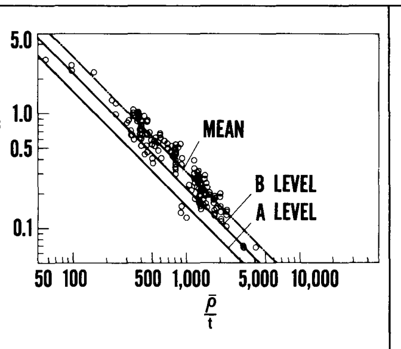

Fig. C8.24

170の試験から得られたデータが、期待される90%および99%の確率強度レベルに対して統計的に評価された。データのばらつきは、モノコック円筒のそれよりもわずかに小さいことがわかった。半径対厚さ比の非線形効果、または長さ対半径比に伴う強度低下は認められなかった。

図 C8.24 の「A」レベル曲線は、95%の信頼度で全試験母集団の少なくとも99%によって上回るレベルである。すなわち、すべての円錐の圧縮強度の少なくとも99%が「A」レベル曲線を上回ることが期待される信頼度は95%である。「B」レベル曲線は、90%の確率と95%の信頼度に対するものである。

「A」および「B」曲線は、実用的な設計のために推奨される。単一の破損が人員の壊滅的な損失または負傷につながるような構造物には、「A」レベル曲線を使用することが推奨される。非弾性応力によって引き起こされる早期の破損の可能性を排除するために、円錐の小端における応力レベルをチェックする必要がある。

## C8.19 薄肉円錐殻の追加の設計座屈曲線

図 C8.25、26、27 は、それぞれ圧縮、曲げ、およびねじりにおける薄肉円錐殻の許容座屈応力を決定するための曲線を示している。これらの曲線は、ボーイング社のご厚意により、同社のレポート D2-3617 から転載したものである。図 C8.28 は、同じボーイング社のレポートからの、薄肉円錐殻の許容外圧座屈応力の設計曲線を示している。これらの曲線は、ミニットマンのインターステージおよびスカートの設計に使用され、円錐殻は（文献17）に示されている方法によって設計されたリング補強材を有していた。

### 用語の定義:

- $F_c$ = 許容圧縮座屈応力 (psi)
- $F_b$ = 許容曲げ座屈応力 (psi)
- $F_{st}$ = 許容ねじり座屈応力 (psi)
- $f_c$ = 圧縮応力
- $f_b$ = 曲げ応力
- $f_v$ = 横せん断応力
- $L$ = 円錐殻の傾斜高さ
- $t$ = 壁の厚さ
- $\alpha$ = 円錐の半頂角
- $u_e$ = ポアソン比
- $\rho$ = 最小曲率半径
- $\rho_{avg}$ = 平均曲率半径
- $q$ = 外圧 (psi)
- $q_{cr}$ = 許容外圧

### 複合荷重下の座屈

ボーイング社のレポート (D2-3617) から、同時圧縮、曲げ、せん断、および過圧の影響は、以下の相互作用式を使用して考慮することができる。

$$(R_c + R_b + R_v)^{1.2} + R_q^{1.2} = 1$$

ここで、

$$R_c = f_c/F_c, \quad R_b = f_b/F_b,
\quad R_v = \frac{f_v}{1.4 F_{st}}, \quad R_q = q/q_{cr}$$

## C8.20 例題

壁厚 $t = .05$ 、および図 (a) に示す他の寸法を持つ円錐殻が、アルミニウム合金 ( $E = 10,700,000$ ) から製造されている。以下の値を決定せよ。

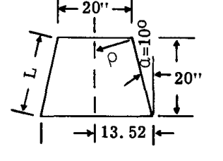

Fig. a

1. 許容圧縮荷重 $P_c$
2. 許容曲げモーメント $M_{cr}$
3. 許容ねじりモーメント $T_{cr}$
4. 許容外圧座屈圧力 $q_{cr}$

### 解答:

$$\begin{aligned}
\rho & = 10 / \cos 10^\circ = 10.16 \text{ in.} \\
\rho/t & = 10.16 / .05 = 203 \\
L & = 20 / \cos 10^\circ = 20.32 \text{ in.} \\
L/\rho & = 20.32 / 10.16 = 2.0
\end{aligned}$$

#### $P_c$ を求める:

図 C8.25 から、 $\rho/t = 203$ および $L/\rho = 2.0$ に対して、 $F_c \times 10^3/E$ は 1.20 に等しいと読み取る。したがって、

$$\begin{aligned}
F_c & = 1.20 \times 10,700,000 / 1000 = 12,820 \text{ psi} \\
P_c & = F_c 2\pi r t \\
& = 12820 \times 2\pi \times 10 \times .05 = 40,300 \text{ lbs.}
\end{aligned}$$

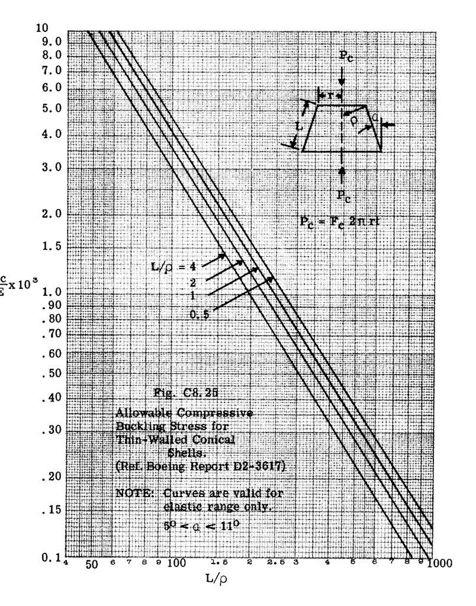

Fig. C8.25

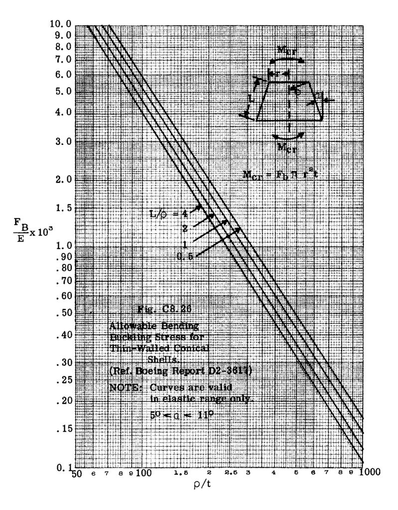

Fig. C8.26

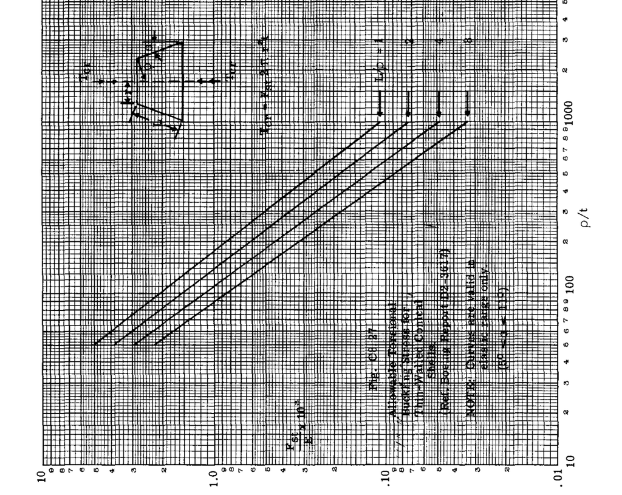

Fig. C8.27

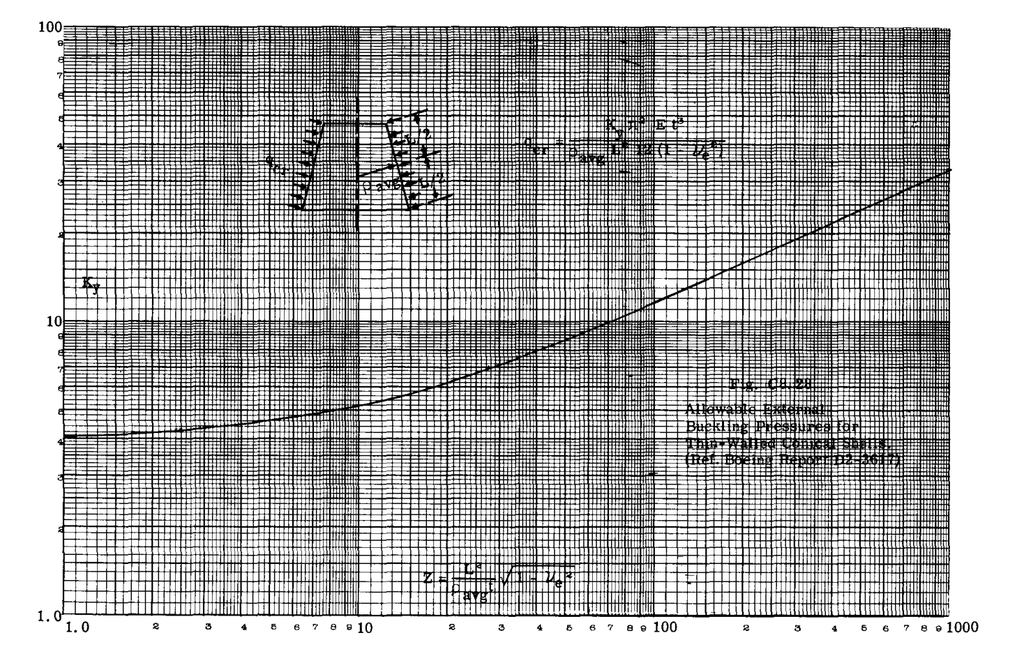

Fig. C8.28

#### $M_{cr}$ を求める:

図 C8.26 から、 $\rho/t = 203$ および $L/\rho = 2.0$ に対して、 $F_b \times 10^3/E = 1.48$ と読み取る。したがって、 $F_b = 1.48 \times 10,700,000 / 1000 = 15,820$ psi となる。次に、

$$\begin{aligned}
M_{cr} & = F_b \pi r^2 t \\
& = 15820 \pi \times 10^2 \times .05 = 248,500 \text{ in. lb.}
\end{aligned}$$

#### $T_{cr}$ を求める:

図 C8.27 から、 $\rho/t = 203$ および $L/\rho = 2.0$ に対して、 $F_{st} \times 10^3/E = .61$ と読み取る。したがって、 $F_{st} = .61 \times 10,700,000 / 1000 = 6520$ psi となる。次に、

$$\begin{aligned}
T_{cr} & = F_{st} 2\pi r^2 t \\
& = 6520 \times 2\pi \times 10^2 \times .05 = 205,000 \text{ in.
lb.}
\end{aligned}$$

#### 許容外圧座屈圧力 $q_{cr}$ を求める:

図 C8.28 を使用する。

$$\begin{aligned}
\rho_{avg} & = \frac{10 + 13.52}{2 \cos 10^\circ} = 11.92 \text{
in.} \\
\rho_{avg}/t & = 11.92 / .05 = 238
\end{aligned}$$

図 C8.28 の下部スケールパラメータは、

$$\begin{aligned}
Z & = \frac{L^2}{\rho_{avg} t} \sqrt{1 -
u_e^2} \\
Z & = \frac{20.32^2}{11.92 \times .05} \sqrt{1 - .3^2} = 660
\end{aligned}$$

## 演習問題

1. $E = 10,500,000$ のアルミニウム合金から製造された円筒モノコック。壁厚は .064。円筒直径は 80 インチ。長さは 60 インチ。90%の確率因子を使用して、以下の値を決定せよ。
1. 円筒の座屈圧縮荷重。
2. 円筒の座屈曲げモーメント。
3. 円筒の座屈ねじりモーメント。
2. 問題(1)の円筒に、以下の設計荷重が加わっている。円筒はこれらの様々な設計条件下で破損するか。

#### 条件1

$P = 30000$ lbs. 圧縮 $M = 50000$ in. lbs.

#### 条件2

$P = 25000$ lbs. 圧縮 $M = 45000$ in. lbs. $T = 50000$ in. lbs.

3. 問題1の円筒が 6 psi に加圧されている場合、それが支持できる極限圧縮荷重はいくらか。耐えられる極限曲げモーメントはいくらか。耐えられる極限ねじりモーメントはいくらか。
4. 円錐殻の小端直径が 30 インチ、長さが 30 インチ、半頂角が 8 度、壁厚が .057 である。材料は $E = 10,500,000$ のアルミニウム合金である。各荷重が個別に作用する場合に、円錐が耐えられる極限圧縮荷重、極限曲げモーメント、および極限ねじりモーメントを決定せよ。

円錐を座屈させる外圧を決定せよ。

## 参考文献

1. Harris, Seurer, Skeene and Benjamin. The Stability of Thin-Walled Unstiffened Circular Cylinders Under Axial Compression. Jour. Aero. Sciences. Vol. 24, August, 1957.
2. Donnell, L. H. Stability of Thin-Walled Tubes Under Torsion. NACA Report 479.
3. Batdorf, S. B. A Simplified Method of Elastic Stability Analysis for Thin Cylindrical Shells. NACA Report 874 (1947).
4. Weingarten, Morgan and Siede. Final Report of Design Criteria for Elastic Stability of Thin Shell Structures. Contract AF04(647)619 Air Force Ballistic Missile Division. Space Tech. Labs. Dec., 1960.
5. Lo, Crate and Schwartz. Buckling of Thin Walled Cylinders Under Axial Compression and Internal Pressure. NACA T. N. 2021, Jan. 1950.
6. VonKarman and Tsien. The Buckling of Thin Cylindrical Shells Under Axial Compression. Jour. of Aero. Sciences. Vol. 8, June 1941.
7. Tsein. A Theory for Buckling of Thin Shells. Jour. of Aero. Sciences. Vol. 9, August 1942.
8. Fung and Sechler. Buckling of Thin Walled Circular Cylinders Under Axial Compression and Internal Pressure. Jour. of Aero. Sciences. Vol. 24, May 1957.
9. Harris, Seurer, Skeene and Benjamin. The Bending Stability of Thin Walled Unstiffened Circular Cylinders Including Effects of Internal Pressure. Jour. of Aero. Sciences, Vol. 25, May 1958.
10. Siede and Weingarten. On the Bending of Circular Cylindrical Shells Under Pure Bending. Jour. of Applied Mechanics. Vol. 28, March 1961.
11. Flugge. Die Stabilität der Kreiszylinderschale. Ingenieur Archiv. Vol. 3, 1932.
12. Gerard & Becker. Handbook of Structural Stability. Part III. Buckling of Curved Plates and Shells. NACA T. N. 3783, Aug. 1957.
13. Hopkins and Brown. The Effect of Internal Pressure on the Initial Buckling of Thin Walled Circular Cylinders Under Torsion. R & M. No. 2423. British A. R. C. 1946.
14. Crate, Batdorf and Baab. The Effect of Internal Pressure on the Buckling Stress of Thin Walled Circular Cylinders Under Torsion. NACA WRL-67, 1940.
15. Batdorf, Stein and Schildcrout. Critical Stress of Thin Walled Cylinders in Torsion. NACA T. N. 1344 (1947).
16. Hausrath & Dittoe. Development of Design Strength Levels for the Elastic Stability of Monocoque Cones Under Axial Compression. NASA T. N. D-1510 (1962).
17. Hess and Garber. Stability of Ring Stiffened Conical Shells Under Simultaneous Lateral Pressure and Axial Compression. General Electric Report No. R58SD226. April 1958.